# A1_AhmedMoselhi

### 0.3.10 Pre-normalization boxplots

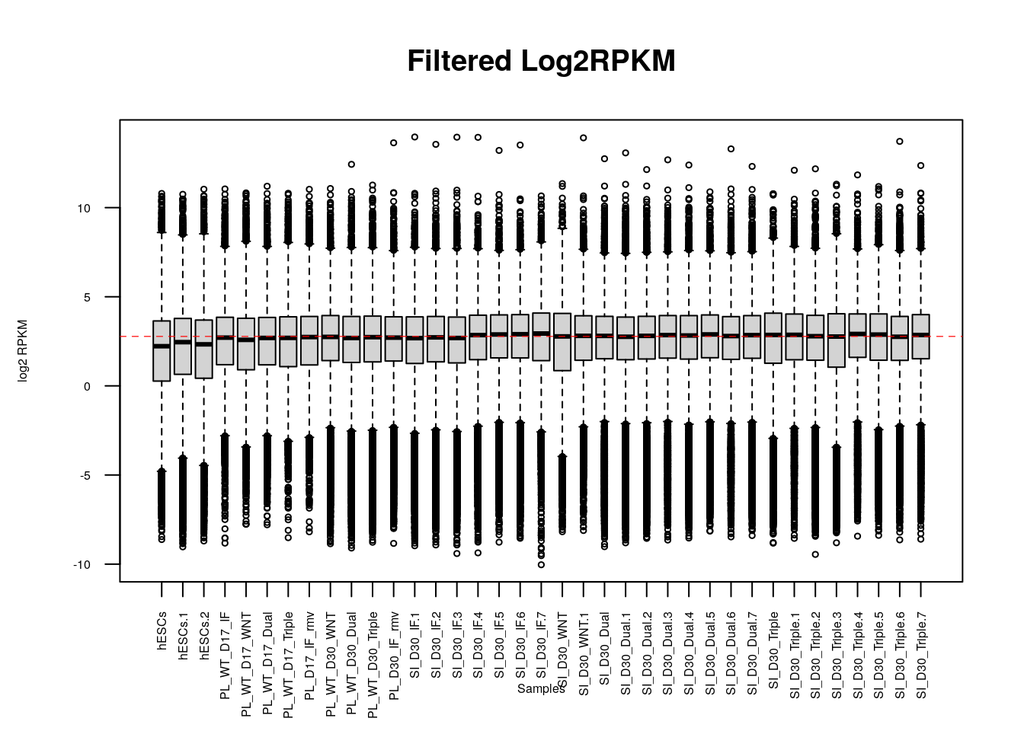

```r
boxplot(filt_data2plot, xlab = "Samples", ylab = "log2 RPKM",
        las = 2, cex = 0.5, cex.lab = 0.5,
        cex.axis = 0.5, main = "Filtered Log2RPKM")
# Median line
abline(h = median(apply(filt_data2plot, 2, median)),
       col = "red", lwd = 0.6, lty = "dashed")
```

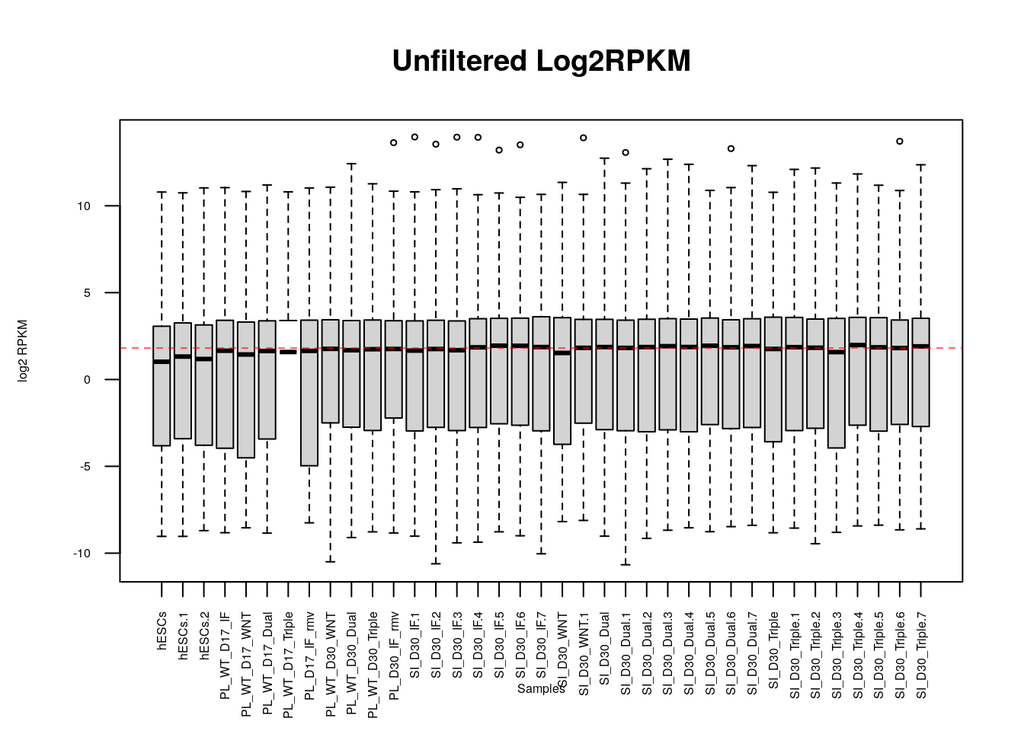

```r
boxplot(unfilt_data2plot, xlab = "Samples", ylab = "log2 RPKM",
        las = 2, cex = 0.5, cex.lab = 0.5,
        cex.axis = 0.5, main = "Unfiltered Log2RPKM")
# Median line
abline(h = median(apply(unfilt_data2plot, 2, median)),
       col = "red", lwd = 0.6, lty = "dashed")
```

## 0.4 Normalization

### 0.4.1 Normalization with edgeR

```r
d <- edgeR::DGEList(counts = filt_bulk_data_num, group = WT_bulk_sample_info$Protocol)

d <- edgeR::calcNormFactors(d)

normalized_counts <-  edgeR::cpm(d)

log2_normalized_counts <- log2(normalized_counts)
```

### 0.4.2 Post-Normalization density and Boxplots

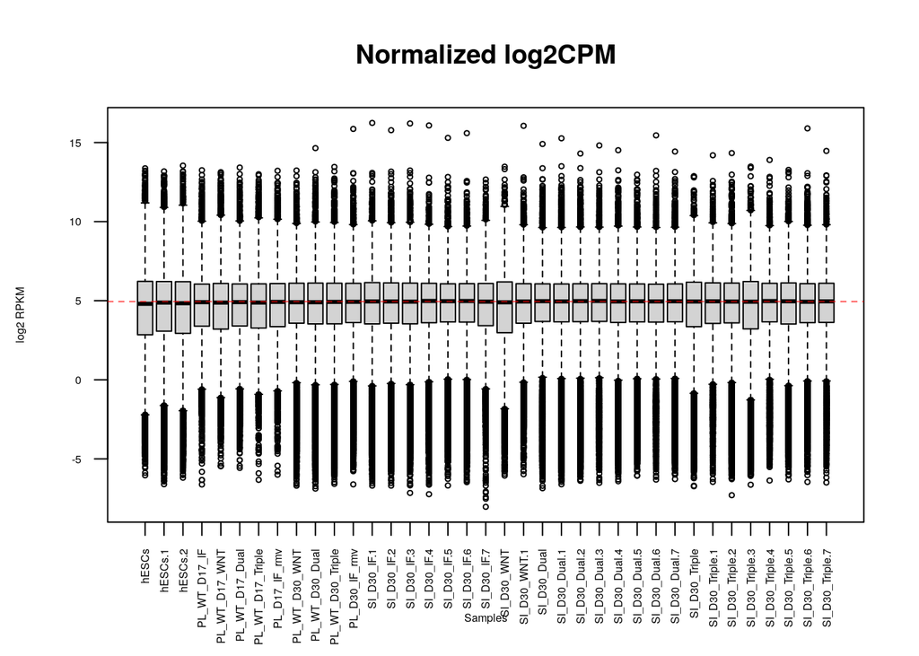

```r
normal_count_density <- apply(log2_normalized_counts, 2, density)

boxplot(log2_normalized_counts, xlab = "Samples", ylab = "log2 RPKM",
        las = 2, cex = 0.5, cex.lab = 0.5,
        cex.axis = 0.5, main = "Normalized log2CPM")
# Median line
abline(h = median(apply(log2_normalized_counts, 2, median)),
       col = "red", lwd = 0.6, lty = "dashed")
```

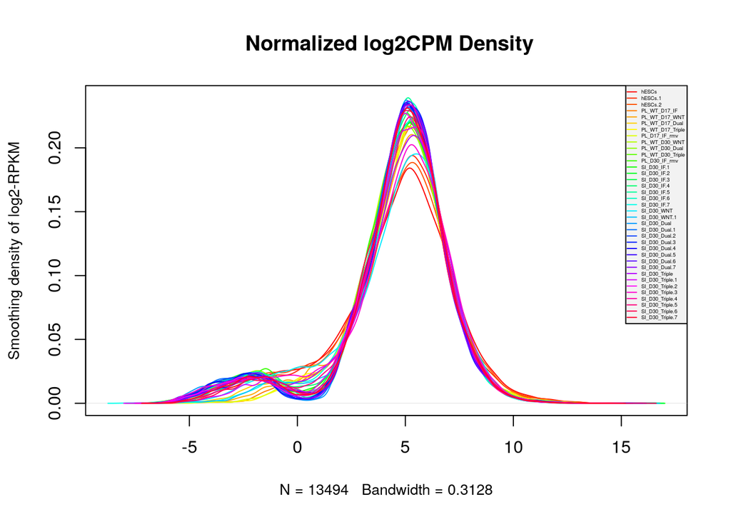

```r
# Density plot for normalized data
xlim <- 0; ylim <- 0
for (i in 1:length(normal_count_density)) {
  xlim <- range(c(xlim, normal_count_density[[i]]$x));
  ylim <- range(c(ylim, normal_count_density[[i]]$y))
}
cols <- rainbow(length(normal_count_density))
ltys <- rep(1, length(normal_count_density))

plot(normal_count_density[[1]], xlim=xlim, ylim=ylim, type="n",
     ylab="Smoothing density of log2-RPKM",
     main=" Normalized log2CPM Density", cex.lab = 0.85)

for (i in 1:length(normal_count_density))
  lines(normal_count_density[[i]], col=cols[i], lty=ltys[i])

legend("topright", colnames(log2_normalized_counts),
       col=cols, lty=ltys, cex=0.3,
       border ="blue", text.col = "black",
       merge = TRUE, bg = "gray95")
```

## Final Dataframe

```r
final_df <- normalized_counts
rownames(final_df) <- rownames(filtered_bulk_data)

kableExtra::kable_styling(knitr::kable(head(final_df)))
```

|  | hESCs | hESCs.1 | hESCs.2 | PL_WT_D17_IF | PL_WT_D17_WNT | PL_WT_D17_Dual | PL_WT_D17_Triple | PL_D17_IF_rmv | PL_WT_D30_WNT | PL_WT_D30_Dual | PL_WT_D30_Triple | PL_D30_IF_rmv | SI_D30_IF.1 | SI_D30_IF.2 | SI_D30_IF.3 | SI_D30_IF.4 | SI_D30_IF.5 | SI_D30_IF.6 | SI_D30_IF.7 | SI_D30_WNT | SI_D30_WNT.1 | SI_D30_Dual | SI_D30_Dual.1 | SI_D30_Dual.2 | SI_D30_Dual.3 | SI_D30_Dual.4 | SI_D30_Dual.5 | SI_D30_Dual.6 | SI_D30_Dual.7 | … |
| --- | --- | --- | --- | --- | --- | --- | --- | --- | --- | --- | --- | --- | --- | --- | --- | --- | --- | --- | --- | --- | --- | --- | --- | --- | --- | --- | --- | --- | --- | --- |
| TSPAN6 | 188.0234443 | 179.7235214 | 178.70368 | 135.00026 | 143.6338819 | 145.40776 | 146.6340510 | 168.50695 | 121.512959 | 112.0428012 | 88.8810831 | 149.2751826 | 172.0475860 | 152.790652 | 173.612708 | 237.489733 | 150.780775 | 218.788943 | 307.9661405 | 35.295881 | 189.275115 | 158.5454755 | 162.4382998 | 177.005662 | 198.8789958 | 172.4249527 | 173.7559359 | 205.066058 | 153.4506519 | … |
| DPM1 | 342.0031232 | 249.9981482 | 264.15286 | 102.68274 | 154.8229591 | 112.02290 | 157.7500540 | 166.00451 | 95.026422 | 105.3719669 | 112.9853458 | 105.6670386 | 104.5824756 | 103.200405 | 122.968478 | 157.922622 | 127.153768 | 177.712078 | 128.2793787 | 97.797542 | 140.447151 | 108.4683444 | 118.0472043 | 133.151607 | 173.4134307 | 123.6221939 | 157.6733916 | 142.541439 | 151.3408563 | … |
| SCYL3 | 17.3572893 | 15.8600996 | 15.96736 | 12.48865 | 17.4698977 | 15.55093 | 14.4757257 | 20.96199 | 25.141521 | 19.1241643 | 18.1397869 | 24.3047117 | 18.0823859 | 18.874078 | 21.099869 | 29.921945 | 24.269311 | 29.551339 | 36.0359627 | 11.387885 | 29.414669 | 18.8792845 | 20.3993522 | 18.498533 | 18.6926837 | 20.6482222 | 22.7643352 | 21.817683 | 29.5174786 | … |
| C1orf112 | 23.5835296 | 24.2189417 | 28.56842 | 26.76453 | 19.4414109 | 18.89046 | 25.9787353 | 16.77296 | 6.600946 | 6.0763956 | 9.8815329 | 4.1854050 | 3.9818413 | 3.895903 | 3.704404 | 6.406002 | 8.389876 | 7.540623 | 4.7912994 | 5.178903 | 4.723885 | 9.5465821 | 7.3773858 | 13.290943 | 12.8582670 | 10.7460678 | 11.2464918 | 9.478221 | 10.7254280 | … |
| CFH | 0.0268251 | 0.0343721 | 0.00000 | 0.00000 | 0.3049903 | 0.00000 | 0.7814489 | 0.00000 | 0.033289 | 0.0146577 | 0.0756682 | 0.1024421 | 0.0333599 | 0.000000 | 0.000000 | 0.000000 | 0.000000 | 0.058364 | 0.3442341 | 0.000000 | 0.000000 | 0.2385012 | 0.1213323 | 0.185919 | 0.0979013 | 0.0212509 | 0.0457585 | 0.372188 | 0.1076902 | … |
| FUCA2 | 152.5871296 | 149.6937869 | 168.38391 | 45.34468 | 57.5918149 | 86.51729 | 91.0541864 | 64.87766 | 43.548392 | 37.7167394 | 23.6465301 | 106.1439856 | 108.7422356 | 82.181711 | 99.377683 | 107.019081 | 67.541629 | 94.816505 | 67.8554141 | 33.291102 | 103.382550 | 60.3097611 | 59.8499329 | 65.393704 | 65.0403564 | 48.6061760 | 61.0017548 | 60.304003 | 56.8529588 | … |

## 0.5 Questions

**1. Why is the dataset of interest to you?**

The past few years of research have grown my interest in outer radial glia (oRGs), a primate neural precursor involved in cortical expansion. oRG abnormality is thought to underly a large number of Neurodevelopmental disorders (NDDs) such as Autism Spectrum Disorder. We’ve only just started studying these cells recently (relative to other cells) and so the potential implications for our understanding of human cognition, development and potential applications are quite exciting.

This study and dataset are particularly interesting to me because of my work with brain organoids. oRGs are quite difficult to culture and they can take up 100 days to appear in 2D culture. In both 3D and 2D cultures, oRG emergence is very variable which restricts reproducibility. This triple inhibition protocol (which I am currently testing in the lab) purports to enhance oRG emergence. I’m curious as to the underlying transcriptomics which may drive the function of this new protocol.

**2. What are the control and test conditions of the dataset?**

The controls of this dataset are day 0 undifferentiated human embryonic stem cells (hESCs). The test conditions compared against these stem cells will be brain organoids grown under 4 different protocols: Inhibitor free, WNT-i, Dual SMAD-i or Triple-i. The “i” in this case, denotes inhibition, whereby the inhibition of specific morphogens can help us fine tune and guide cell development. The secondary condition being examined is time. Day 0 hESCs are compared to all protocols at Day 17 and Day 30 to assess the progression of oRG emergence. All organoids for bulk RNAseq were generated rom the same H9 cell line.

**3. How many samples in each of the conditions of your dataset?**

One interesting feature of this dataset is that some samples are pooled organoids, while others are single organoids.

**4. Were there expression values that were not unique for specific genes? How did you handle these?**

**5. Were there expression values that could not be mapped to current HUGO symbols?**

Mapping was performed here This data set did have HUGO symbols already, so most of the work was done for me. However, ~27/18746 genes did not have a HUGO symbol and instead had numerical HUGO ids. 4 of those genes were the duplicate which meant that 23 genes needed to be mapped. Using biomaRt, I mapped an additional 14 genes. This left me with 9 genes which did not have a HUGO gene entry and could not be verified. To avoid inaccurate mapping, those genes were removed.

**6. Were there any outliers in your dataset? How were they handled in the originating paper? How many outliers were removed?**

This dataset has already been normalized to RPKM and so outliers were already removed. This can be seen in the similarity between filtered and normalized boxplots. The authors did not specify their process for removing outliers.

**7. How did you handle replicates?**

*Duplicates?* There were only 3 duplicated genes in the entire dataset. One gene had 0 expression so that was removed without consideration. The other 2 genes were researched to see if I could differentiate between the two rows given they varied in expression. I was unable to find splice variants or an explanation for either, so I chose to omit those genes as well as to not bias their expression by summing/averaging. Therefore, a total of 6 (3x2) duplicate genes were removed.

*Replicates?* The single organoid samples all had a range between 2-8 replicates. I did not process these yet as I am still deciding the best approach for analyzing them in comparison to the pooled organoids.

**8. What is the final coverage of your dataset?** The final dataset has 13494 genes and 37 samples. Note: The authors chose to only include samples with Refseq annotations.

## 0.6 References

1. Rosebrock D, Arora S, Mutukula N, Volkman R, Gralinska E, Balaskas A, et al. Enhanced cortical neural stem cell identity through short SMAD and WNT inhibition in human cerebral organoids facilitates emergence of outer radial glial cells. Nat Cell Biol. 2022;24(6):981–95.
2. Huber W, Carey VJ, Gentleman R, Anders S, Carlson M, Carvalho BS, Bravo HC, Davis S, Gatto L, Girke T, Gottardo R, Hahne F, Hansen KD, Irizarry RA, Lawrence M, Love MI, MacDonald J, Obenchain V, Oleś AK, Pagès H, Reyes A, Shannon P, Smyth GK, Tenenbaum D, Waldron L, Morgan M. Orchestrating high-throughput genomic analysis with Bioconductor. Nature Methods. 2015;12(2):115–121.
3. Schauberger P, Walker A. openxlsx: Read, Write and Edit xlsx Files. R package version 4.2.5.2. 2023.
4. Davis S, Meltzer P. GEOquery: a bridge between the Gene Expression Omnibus (GEO) and BioConductor. Bioinformatics. 2007;14:1846–1847.
5. Durinck S, Spellman PT, Birney E, Huber W. Mapping identifiers for the integration of genomic datasets with the R/Bioconductor package biomaRt. Nature Protocols. 2009;4:1184–1191.
6. Barrett T, Dowle M, Srinivasan A. data.table: Extension of data.frame. R package version 1.14.10. 2023. Available from: https://CRAN.R-project.org/package=data.table
7. Robinson MD, McCarthy DJ, Smyth GK. edgeR: a Bioconductor package for differential expression analysis of digital gene expression data. Bioinformatics. 2010;26(1):139-140.
8. Kriegstein A, Noctor S, Martínez-Cerdeño V. Patterns of neural stem and progenitor cell division may underlie evolutionary cortical expansion. Nat Rev Neurosci. 2006 Nov;7(11):883–90.
9. Pollen AA, Nowakowski TJ, Chen J, Retallack H, Sandoval-Espinosa C, Nicholas CR, et al. Molecular Identity of Human Outer Radial Glia During Cortical Development. Cell. 2015 Sep 24;163(1):55–67.
10. Camp JG, Badsha F, Florio M, Kanton S, Gerber T, Wilsch-Bräuninger M, et al. Human cerebral organoids recapitulate gene expression programs of fetal neocortex development. Proceedings of the National Academy of Sciences. 2015 Dec 22;112(51):15672–7.